# Rafael Nadal Model - Data Wrangling

Examinamos partidos de tenis que van desde el año 2005 hasta el 2021. El objetivo es encontrar el mejor modelo que logre predecir correctamente el resultado de los partidos donde juega Nadal.

Arrancamos con un setup del environment.

```r
pacman::p_load(pacman, tidyverse, lubridate,
               stringr, readxl, magrittr, rio)

options(scipen = 999) #desactivo notación cientifica
```

Importamos la data para trabajar. La misma se encuentra en el sitio http://www.tennis-data.co.uk/alldata.php

```r
for (i in (2005:2012)) {

  path = paste("http://www.tennis-data.co.uk/",i, "/", i, ".xls", sep = "")
  file <- import(path, setclass = "tbl_df")
  file <- file[,1:28]

  file %<>%
    mutate_at(vars(WRank, LRank, WPts, LPts), as.numeric)

  assign(paste("data",i,sep = ""), file)

}
```

[output not shown]

```r
for (i in (2013:2021)) {

  path = paste("http://www.tennis-data.co.uk/",i, "/", i,".xlsx", sep = "")
  file <- import(path, setclass = "tbl_df")
  file <- file[,1:28]

   file %<>%
    mutate_at(vars(WRank, LRank, WPts, LPts), as.numeric)

  assign(paste("data",i,sep = ""), file)

}
```

[output not shown]

```r
rm(file, i , path)
```

Con la data ya lista, la transformamos en un único dataset.

```r
#conceteno todos los datasets

matches <- tibble()

for (i in 2005:2021) {

  matches <- bind_rows(
    matches,
    get(
      paste("data", i, sep = "")
    )[,1:28]
  )

}

for (i in 2005:2021) {

  rm(
      list = paste("data", i, sep = "")
  )

}

rm(i)
```

Ahora corrijo las variables que necesitan ser corregidas y separo los partidos de Nadal en un dataset aparte.

```r
glimpse(matches)
```

```
Rows: 43,068
Columns: 28
$ ATP        <dbl> 1, 1, 1, 1, 1, 1, 1, 1, 1, 1, 1, 1, 1, 1, 1, 1, 1, 1, 1, 1,~
$ Location   <chr> "Adelaide", "Adelaide", "Adelaide", "Adelaide", "Adelaide",~
$ Tournament <chr> "Next Generation Hardcourts", "Next Generation Hardcourts",~
$ Date       <dttm> 2005-01-03, 2005-01-03, 2005-01-03, 2005-01-03, 2005-01-03~
$ Series     <chr> "International", "International", "International", "Interna~
$ Court      <chr> "Outdoor", "Outdoor", "Outdoor", "Outdoor", "Outdoor", "Out~
$ Surface    <chr> "Hard", "Hard", "Hard", "Hard", "Hard", "Hard", "Hard", "Ha~
$ Round      <chr> "1st Round", "1st Round", "1st Round", "1st Round", "1st Ro~
$ `Best of`  <dbl> 3, 3, 3, 3, 3, 3, 3, 3, 3, 3, 3, 3, 3, 3, 3, 3, 3, 3, 3, 3,~
$ Winner     <chr> "Saulnier C.", "Enqvist T.", "Melzer J.", "Rochus O.", "May~
$ Loser      <chr> "Baccanello P.", "Sluiter R.", "Berdych T.", "Dupuis A.", "~
$ WRank      <dbl> 53, 72, 39, 66, 35, 21, 48, 65, 33, 32, 11, 58, 132, 26, 3,~
$ LRank      <dbl> 324, 82, 45, 79, 101, 57, 68, 76, 88, 63, 309, 77, 220, 75,~
$ WPts       <dbl> NA, NA, NA, NA, NA, NA, NA, NA, NA, NA, NA, NA, NA, NA, NA,~
$ LPts       <dbl> NA, NA, NA, NA, NA, NA, NA, NA, NA, NA, NA, NA, NA, NA, NA,~
$ W1         <dbl> 6, 6, 6, 6, 6, 6, 6, 6, 6, 6, 6, 6, 6, 6, 2, 3, 6, 6, 6, 6,~
$ L1         <dbl> 2, 3, 4, 3, 4, 2, 2, 3, 3, 1, 2, 4, 4, 1, 6, 6, 3, 4, 0, 7,~
$ W2         <dbl> 7, 6, 4, 3, 3, 2, 7, 6, 6, 2, 6, 3, 7, 6, 6, 7, 6, 6, 6, 6,~
$ L2         <dbl> 6, 1, 6, 6, 6, 1, 6, 4, 4, 6, 4, 6, 6, 1, 1, 5, 3, 3, 3, 3,~
$ W3         <dbl> NA, NA, 7, 6, 7, NA, NA, NA, NA, 6, NA, 7, NA, NA, 6, 6, NA~
$ L3         <dbl> NA, NA, 6, 1, 5, NA, NA, NA, NA, 2, NA, 6, NA, NA, 1, 2, NA~
$ W4         <dbl> NA, NA, NA, NA, NA, NA, NA, NA, NA, NA, NA, NA, NA, NA, NA,~
$ L4         <dbl> NA, NA, NA, NA, NA, NA, NA, NA, NA, NA, NA, NA, NA, NA, NA,~
$ W5         <dbl> NA, NA, NA, NA, NA, NA, NA, NA, NA, NA, NA, NA, NA, NA, NA,~
$ L5         <dbl> NA, NA, NA, NA, NA, NA, NA, NA, NA, NA, NA, NA, NA, NA, NA,~
$ Wsets      <dbl> 2, 2, 2, 2, 2, 1, 2, 2, 2, 2, 2, 2, 2, 2, 2, 2, 2, 2, 2, 2,~
$ Lsets      <dbl> 0, 0, 1, 1, 1, 0, 0, 0, 0, 1, 0, 1, 0, 0, 1, 1, 0, 0, 0, 1,~
$ Comment    <chr> "Completed", "Completed", "Completed", "Completed", "Comple~
```

```r
#corrijo nombres de variables

colnames(matches)[9] = "BestOf"

#corrijo data types

summary(matches) #location, series, court, surface, round y comment son factores
```

```
      ATP          Location          Tournament
 Min.   : 1.00   Length:43068       Length:43068
 1st Qu.:18.00   Class :character   Class :character
 Median :31.00   Mode  :character   Mode  :character
 Mean   :31.98
 3rd Qu.:48.00
 Max.   :67.00

      Date                        Series             Court
 Min.   :2005-01-03 00:00:00   Length:43068       Length:43068
 1st Qu.:2008-08-25 00:00:00   Class :character   Class :character
 Median :2012-08-30 00:00:00   Mode  :character   Mode  :character
 Mean   :2012-10-25 10:02:10
 3rd Qu.:2016-10-14 00:00:00
 Max.   :2021-06-26 00:00:00

   Surface             Round               BestOf         Winner
 Length:43068       Length:43068       Min.   :3.000   Length:43068
 Class :character   Class :character   1st Qu.:3.000   Class :character
 Mode  :character   Mode  :character   Median :3.000   Mode  :character
                                       Mean   :3.384
                                       3rd Qu.:3.000
                                       Max.   :5.000

    Loser               WRank             LRank              WPts
 Length:43068       Min.   :   1.00   Min.   :   1.00   Min.   :    1
 Class :character   1st Qu.:  16.00   1st Qu.:  35.00   1st Qu.:  628
 Mode  :character   Median :  41.00   Median :  64.00   Median : 1003
                    Mean   :  58.09   Mean   :  90.31   Mean   : 1813
                    3rd Qu.:  76.00   3rd Qu.: 103.00   3rd Qu.: 1890
                    Max.   :1890.00   Max.   :2159.00   Max.   :16950
                    NA's   :16        NA's   :98        NA's   :1690
      LPts             W1              L1              W2
 Min.   :    1   Min.   :0.000   Min.   :0.000   Min.   :0.000
 1st Qu.:  490   1st Qu.:6.000   1st Qu.:3.000   1st Qu.:6.000
 Median :  746   Median :6.000   Median :4.000   Median :6.000
 Mean   : 1050   Mean   :5.802   Mean   :4.077   Mean   :5.782
 3rd Qu.: 1155   3rd Qu.:6.000   3rd Qu.:6.000   3rd Qu.:6.000
 Max.   :16950   Max.   :7.000   Max.   :7.000   Max.   :7.000
 NA's   :1770    NA's   :255     NA's   :252     NA's   :667
```

[output cut: 9 more lines]

```
 Min.   :0.00    Min.   : 1.00   Min.   : 0.00   Min.   :0.00
 1st Qu.:2.00    1st Qu.: 6.00   1st Qu.: 2.00   1st Qu.:2.00
 Median :4.00    Median : 6.00   Median : 4.00   Median :2.00
 Mean   :3.87    Mean   : 6.64   Mean   : 3.78   Mean   :2.15
 3rd Qu.:6.00    3rd Qu.: 7.00   3rd Qu.: 5.00   3rd Qu.:2.00
 Max.   :7.00    Max.   :70.00   Max.   :68.00   Max.   :3.00
 NA's   :39121   NA's   :41574   NA's   :41574   NA's   :249
     Lsets          Comment
 Min.   :0.0000   Length:43068
 1st Qu.:0.0000   Class :character
 Median :0.0000   Mode  :character
 Mean   :0.4099
 3rd Qu.:1.0000
 Max.   :2.0000
 NA's   :251
```

```r
matches %<>%
  mutate_at(vars(Location, Series, Court, Surface, Round, Comment, BestOf),
            as.factor)

summary(matches)
```

```
      ATP                Location      Tournament
 Min.   : 1.00   Paris       : 2919   Length:43068
 1st Qu.:18.00   Melbourne   : 2269   Class :character
 Median :31.00   New York    : 2168   Mode  :character
 Mean   :31.98   London      : 2085
 3rd Qu.:48.00   Miami       : 1520
 Max.   :67.00   Indian Wells: 1425
                 (Other)     :30682
      Date                               Series          Court
 Min.   :2005-01-03 00:00:00   ATP250       :13711   Indoor : 7796
 1st Qu.:2008-08-25 00:00:00   Grand Slam   : 8255   Outdoor:35272
 Median :2012-08-30 00:00:00   Masters 1000 : 6653
 Mean   :2012-10-25 10:02:10   International: 5269
 3rd Qu.:2016-10-14 00:00:00   ATP500       : 4970
 Max.   :2021-06-26 00:00:00   Masters      : 2316
                               (Other)      : 1894
   Surface                Round       BestOf       Winner
 Carpet:  839   1st Round    :19609   3:34793   Length:43068
 Clay  :13855   2nd Round    :12048   5: 8275   Class :character
 Grass : 4781   Quarterfinals: 4148             Mode  :character
 Hard  :23593   3rd Round    : 3024
                Semifinals   : 2106
                The Final    : 1053
                (Other)      : 1080
    Loser               WRank             LRank              WPts
 Length:43068       Min.   :   1.00   Min.   :   1.00   Min.   :    1
 Class :character   1st Qu.:  16.00   1st Qu.:  35.00   1st Qu.:  628
 Mode  :character   Median :  41.00   Median :  64.00   Median : 1003
                    Mean   :  58.09   Mean   :  90.31   Mean   : 1813
                    3rd Qu.:  76.00   3rd Qu.: 103.00   3rd Qu.: 1890
                    Max.   :1890.00   Max.   :2159.00   Max.   :16950
                    NA's   :16        NA's   :98        NA's   :1690
      LPts             W1              L1              W2
 Min.   :    1   Min.   :0.000   Min.   :0.000   Min.   :0.000
 1st Qu.:  490   1st Qu.:6.000   1st Qu.:3.000   1st Qu.:6.000
 Median :  746   Median :6.000   Median :4.000   Median :6.000
 Mean   : 1050   Mean   :5.802   Mean   :4.077   Mean   :5.782
 3rd Qu.: 1155   3rd Qu.:6.000   3rd Qu.:6.000   3rd Qu.:6.000
 Max.   :16950   Max.   :7.000   Max.   :7.000   Max.   :7.000
 NA's   :1770    NA's   :255     NA's   :252     NA's   :667
```

[output cut: 9 more lines]

```
 Min.   :0.00    Min.   : 1.00   Min.   : 0.00   Min.   :0.00
 1st Qu.:2.00    1st Qu.: 6.00   1st Qu.: 2.00   1st Qu.:2.00
 Median :4.00    Median : 6.00   Median : 4.00   Median :2.00
 Mean   :3.87    Mean   : 6.64   Mean   : 3.78   Mean   :2.15
 3rd Qu.:6.00    3rd Qu.: 7.00   3rd Qu.: 5.00   3rd Qu.:2.00
 Max.   :7.00    Max.   :70.00   Max.   :68.00   Max.   :3.00
 NA's   :39121   NA's   :41574   NA's   :41574   NA's   :249
     Lsets                Comment
 Min.   :0.0000   Awarded     :    2
 1st Qu.:0.0000   Completed   :41444
 Median :0.0000   Disqualified:    2
 Mean   :0.4099   Retired     : 1371
 3rd Qu.:1.0000   Sched       :    1
 Max.   :2.0000   Walkover    :  248
 NA's   :251
```

```r
#veo si es necesario corregir Location

nlevels(matches$Location)
```

```
[1] 109
```

```r
unique(matches$Location)
```

```
  [1] Adelaide         Chennai          Doha             Auckland
  [5] Sydney           Melbourne        Delray Beach     Milan
  [9] Vina del Mar     Buenos Aires     Marseille        San Jose
 [13] Costa Do Sauipe  Memphis          Rotterdam        Acapulco
 [17] Dubai            Scottsdale       Indian Wells     Miami
 [21] Casablanca       Valencia         Monte Carlo      Barcelona
 [25] Houston          Estoril          Munich           Rome
 [29] Hamburg          St. Polten       Paris            Halle
 [33] Queens Club      's-Hertogenbosch Nottingham       London
 [37] Bastad           Gstaad           Newport          Amersfoort
 [41] Indianapolis     Stuttgart        Kitzbuhel        Los Angeles
 [45] Umag             Sopot            Washington       Montreal
 [49] Cincinnati       New Haven        New York         Beijing
 [53] Bucharest        Bangkok          Ho Chi Min City  Palermo
 [57] Metz             Tokyo            Moscow           Stockholm
 [61] Vienna           Madrid           Basel            Lyon
 [65] St. Petersburg   Shanghai         Zagreb           Las Vegas
 [69] Portschach       Toronto          Mumbai           Warsaw
 [73] Brisbane         Johannesburg     Belgrade         Eastbourne
 [77] Kuala Lumpur     Santiago         Nice             Atlanta
 [81] Montpellier      Winston-Salem    Sao Paulo        Oeiras
 [85] Dusseldorf       Bogota           Rio de Janeiro   Shenzhen
 [89] Quito            Istanbul         Geneva           Sofia
 [93] Marrakech        Los Cabos        Chengdu          Antwerp
 [97] Budapest         Antalya          Pune             Cordoba
[101] Zhuhai           Cologne          Sardinia         Nur-Sultan
[105] Singapore        Cagliari         Marbella         Parma
[109] Mallorca
109 Levels: 's-Hertogenbosch Acapulco Adelaide Amersfoort Antalya ... Zhuhai
```

```r
#Separo partidos donde jugó Nadal

nadalw <- matches$Winner %>%
  str_detect("Nadal") %>%
  which()

matches$Winner[nadalw] %>%
  unique() #Nadal R. es el unico nombre con el que aparece Nadal
```

```
[1] "Nadal R."
```

```r
nadalL <- matches$Loser %>%
  str_detect("Nadal") %>%
  which()

matches$Loser[nadalL] %>%
  unique() #Nadal R. es el unico nombre con el que aparece
```

```
[1] "Nadal R."
```

```r
#Ahora separo el dataset según los partidos donde participó nadal

matches_nadal <- matches %>%
  filter(Winner == "Nadal R." |
          Loser == "Nadal R."
  )

nrow(matches_nadal) - length(nadalL) - length(nadalw) #si da 0 está OK
```

```
[1] 0
```

```r
rm(nadalL, nadalw)

glimpse(matches_nadal)
```

```
Rows: 1,129
Columns: 28
$ ATP        <dbl> 3, 3, 3, 4, 6, 6, 6, 6, 10, 10, 10, 13, 13, 13, 13, 13, 16,~
$ Location   <fct> Doha, Doha, Doha, Auckland, Melbourne, Melbourne, Melbourne~
$ Tournament <chr> "Qatar Exxon Mobil Open", "Qatar Exxon Mobil Open", "Qatar ~
$ Date       <dttm> 2005-01-04, 2005-01-05, 2005-01-06, 2005-01-11, 2005-01-18~
$ Series     <fct> International, International, International, International,~
$ Court      <fct> Outdoor, Outdoor, Outdoor, Outdoor, Outdoor, Outdoor, Outdo~
$ Surface    <fct> Hard, Hard, Hard, Hard, Hard, Hard, Hard, Hard, Clay, Clay,~
$ Round      <fct> 1st Round, 2nd Round, Quarterfinals, 1st Round, 1st Round, ~
$ BestOf     <fct> 3, 3, 3, 3, 5, 5, 5, 5, 3, 3, 3, 3, 3, 3, 3, 3, 3, 3, 3, 3,~
$ Winner     <chr> "Nadal R.", "Nadal R.", "Ljubicic I.", "Hrbaty D.", "Nadal ~
$ Loser      <chr> "Youzhny M.", "Verdasco F.", "Nadal R.", "Nadal R.", "Benne~
$ WRank      <dbl> 51, 51, 22, 20, 56, 56, 56, 3, 48, 48, 8, 48, 48, 48, 48, 4~
$ LRank      <dbl> 16, 36, 51, 50, 65, 15, 283, 56, 61, 66, 48, 55, 86, 60, 56~
$ WPts       <dbl> NA, NA, NA, NA, NA, NA, NA, NA, NA, NA, NA, NA, NA, NA, NA,~
$ LPts       <dbl> NA, NA, NA, NA, NA, NA, NA, NA, NA, NA, NA, NA, NA, NA, NA,~
$ W1         <dbl> 6, 6, 6, 6, 6, 6, 6, 7, 7, 6, 0, 7, 6, 6, 2, 6, 6, 7, 7, 6,~
$ L1         <dbl> 3, 2, 2, 3, 0, 1, 1, 5, 6, 1, 6, 6, 3, 2, 6, 0, 4, 6, 5, 4,~
$ W2         <dbl> 7, 6, 6, NA, 6, 4, 6, 3, 6, 6, 6, 6, 6, 6, 6, 6, 6, 6, 6, 6~
$ L2         <dbl> 6, 4, 7, NA, 4, 6, 1, 6, 3, 3, 0, 3, 3, 7, 2, 7, 4, 2, 3, 1~
$ W3         <dbl> NA, NA, 6, NA, 6, 4, 6, 1, NA, NA, 6, NA, NA, 6, 6, 6, NA, ~
$ L3         <dbl> NA, NA, 3, NA, 2, 6, 3, 6, NA, NA, 1, NA, NA, 4, 4, 1, NA, ~
$ W4         <dbl> NA, NA, NA, NA, NA, 7, NA, 7, NA, NA, NA, NA, NA, NA, NA, N~
$ L4         <dbl> NA, NA, NA, NA, NA, 5, NA, 6, NA, NA, NA, NA, NA, NA, NA, N~
$ W5         <dbl> NA, NA, NA, NA, NA, 6, NA, 6, NA, NA, NA, NA, NA, NA, NA, N~
$ L5         <dbl> NA, NA, NA, NA, NA, 3, NA, 2, NA, NA, NA, NA, NA, NA, NA, N~
$ Wsets      <dbl> 2, 2, 2, 1, 3, 3, 3, 3, 2, 2, 2, 2, 2, 2, 2, 2, 2, 2, 2, 2,~
$ Lsets      <dbl> 0, 0, 1, 0, 0, 2, 0, 2, 0, 0, 1, 0, 0, 1, 1, 1, 0, 0, 0, 0,~
$ Comment    <fct> Completed, Completed, Completed, Retired, Completed, Comple~
```

Ahora paso a calcular las medidas de interés para los modelos.

```r
matches_nadal$Result <- rep(NA, nrow(matches_nadal))

ganados <- which(
  matches_nadal$Winner == "Nadal R.")
perdidos <- which(
  matches_nadal$Loser == "Nadal R.")

matches_nadal$Result[ganados] <- "Win"
matches_nadal$Result[perdidos] <- "Lose"

matches_nadal$Result <- matches_nadal$Result %>% as.factor()

summary(matches_nadal)
```

```
      ATP               Location    Tournament
 Min.   : 1.00   Paris      :139   Length:1129
 1st Qu.:20.00   London     : 90   Class :character
 Median :29.00   Melbourne  : 81   Mode  :character
 Mean   :31.34   Monte Carlo: 76
 3rd Qu.:47.00   Rome       : 75
 Max.   :67.00   New York   : 72
                 (Other)    :596
      Date                               Series        Court        Surface
 Min.   :2005-01-04 00:00:00   Masters 1000 :340   Indoor : 109   Carpet:  8
 1st Qu.:2008-05-15 00:00:00   Grand Slam   :324   Outdoor:1020   Clay  :459
 Median :2011-11-24 00:00:00   Masters      :134                  Grass : 88
 Mean   :2012-05-12 21:40:58   ATP500       :133                  Hard  :574
 3rd Qu.:2016-02-18 00:00:00   ATP250       : 61
 Max.   :2021-06-11 00:00:00   International: 58
                               (Other)      : 79
           Round     BestOf     Winner             Loser
 2nd Round    :241   3:796   Length:1129        Length:1129
 Quarterfinals:207   5:333   Class :character   Class :character
 3rd Round    :181           Mode  :character   Mode  :character
 Semifinals   :166
 The Final    :122
 1st Round    :113
 (Other)      : 99
     WRank             LRank             WPts            LPts
 Min.   :  1.000   Min.   :  1.00   Min.   :    1   Min.   :    1.0
 1st Qu.:  2.000   1st Qu.:  7.00   1st Qu.: 4645   1st Qu.:  733.8
 Median :  2.000   Median : 27.00   Median : 6700   Median : 1320.0
 Mean   :  7.293   Mean   : 46.31   Mean   : 7198   Mean   : 2745.8
 3rd Qu.:  5.000   3rd Qu.: 63.00   3rd Qu.: 9715   3rd Qu.: 3877.5
 Max.   :690.000   Max.   :694.00   Max.   :16585   Max.   :15360.0
                                    NA's   :57      NA's   :57
       W1              L1              W2             L2              W3
 Min.   :0.000   Min.   :0.000   Min.   :0.00   Min.   :0.000   Min.   :0.000
 1st Qu.:6.000   1st Qu.:2.000   1st Qu.:6.00   1st Qu.:2.000   1st Qu.:6.000
 Median :6.000   Median :4.000   Median :6.00   Median :3.000   Median :6.000
 Mean   :5.875   Mean   :3.588   Mean   :5.89   Mean   :3.423   Mean   :6.029
 3rd Qu.:6.000   3rd Qu.:5.000   3rd Qu.:6.00   3rd Qu.:5.000   3rd Qu.:6.000
 Max.   :7.000   Max.   :7.000   Max.   :7.00   Max.   :7.000   Max.   :7.000
 NA's   :16      NA's   :15      NA's   :22     NA's   :22      NA's   :614
       L3              W4              L4              W5
 Min.   :0.000   Min.   :2.000   Min.   :0.000   Min.   : 2.000
 1st Qu.:2.000   1st Qu.:6.000   1st Qu.:2.000   1st Qu.: 6.000
 Median :3.000   Median :6.000   Median :4.000   Median : 6.000
 Mean   :3.315   Mean   :5.837   Mean   :3.683   Mean   : 6.706
 3rd Qu.:4.500   3rd Qu.:6.000   3rd Qu.:5.250   3rd Qu.: 7.000
 Max.   :7.000   Max.   :7.000   Max.   :7.000   Max.   :15.000
 NA's   :614     NA's   :1025    NA's   :1025    NA's   :1095
       L5             Wsets           Lsets                Comment
 Min.   : 0.000   Min.   :0.000   Min.   :0.0000   Awarded     :   0
 1st Qu.: 2.250   1st Qu.:2.000   1st Qu.:0.0000   Completed   :1087
 Median : 4.000   Median :2.000   Median :0.0000   Disqualified:   0
 Mean   : 4.206   Mean   :2.263   Mean   :0.2971   Retired     :  26
 3rd Qu.: 5.750   3rd Qu.:3.000   3rd Qu.:1.0000   Sched       :   1
 Max.   :13.000   Max.   :3.000   Max.   :2.0000   Walkover    :  15
 NA's   :1095     NA's   :14      NA's   :15
  Result
 Lose:179
 Win :950
```

Ranking del ganador y del perdedor del partido:

```r
matches_nadal$RankNadal <- rep(NA, nrow(matches_nadal))
matches_nadal$RankRival <- rep(NA, nrow(matches_nadal))

matches_nadal$RankNadal[ganados] <-
  matches_nadal$WRank[ganados]

matches_nadal$RankNadal[perdidos] <-
  matches_nadal$LRank[perdidos]

matches_nadal$RankRival[ganados] <-
  matches_nadal$LRank[ganados]

matches_nadal$RankRival[perdidos] <-
  matches_nadal$WRank[perdidos]

matches_nadal %>%
  select(Tournament, WRank, LRank, Result, RankNadal, RankRival) %>%
  print(n = 20)
```

| Tournament | WRank | LRank | Result | RankNadal | RankRival |
| --- | --- | --- | --- | --- | --- |
| Qatar Exxon Mobil Open | 51 | 16 | Win | 51 | 16 |
| Qatar Exxon Mobil Open | 51 | 36 | Win | 51 | 36 |
| Qatar Exxon Mobil Open | 22 | 51 | Lose | 51 | 22 |
| Heineken Open | 20 | 50 | Lose | 50 | 20 |
| Australian Open | 56 | 65 | Win | 56 | 65 |
| Australian Open | 56 | 15 | Win | 56 | 15 |
| Australian Open | 56 | 283 | Win | 56 | 283 |
| Australian Open | 3 | 56 | Lose | 56 | 3 |
| ATP Buenos Aires 2005 | 48 | 61 | Win | 48 | 61 |
| ATP Buenos Aires 2005 | 48 | 66 | Win | 48 | 66 |

[output cut: 990 more lines]

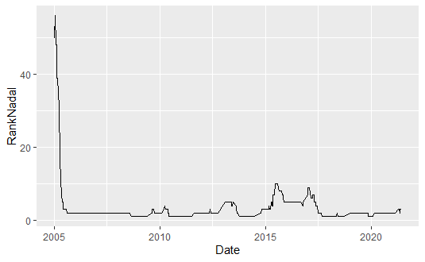

```r
#visualizaciones interesantes
matches_nadal %>% ggplot(aes(x = Date, y = RankNadal)) +
  geom_line()
```

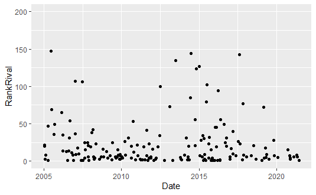

```r
matches_nadal %>% filter(Result == "Lose") %>%
  ggplot(aes(x = Date, y = RankRival)) +
  geom_point() +
  coord_cartesian(ylim = c(0,200))
```

Nombre del rival:

```r
matches_nadal$RivalName <- rep(NA, nrow(matches_nadal))

matches_nadal$RivalName[ganados] <-
  matches_nadal$Loser[ganados]

matches_nadal$RivalName[perdidos] <-
  matches_nadal$Winner[perdidos]

matches_nadal$RivalName <- matches_nadal$RivalName %>%
  as.factor()

summary(matches_nadal)
```

```
      ATP               Location    Tournament
 Min.   : 1.00   Paris      :139   Length:1129
 1st Qu.:20.00   London     : 90   Class :character
 Median :29.00   Melbourne  : 81   Mode  :character
 Mean   :31.34   Monte Carlo: 76
 3rd Qu.:47.00   Rome       : 75
 Max.   :67.00   New York   : 72
                 (Other)    :596
      Date                               Series        Court        Surface
 Min.   :2005-01-04 00:00:00   Masters 1000 :340   Indoor : 109   Carpet:  8
 1st Qu.:2008-05-15 00:00:00   Grand Slam   :324   Outdoor:1020   Clay  :459
 Median :2011-11-24 00:00:00   Masters      :134                  Grass : 88
 Mean   :2012-05-12 21:40:58   ATP500       :133                  Hard  :574
 3rd Qu.:2016-02-18 00:00:00   ATP250       : 61
 Max.   :2021-06-11 00:00:00   International: 58
                               (Other)      : 79
           Round     BestOf     Winner             Loser
 2nd Round    :241   3:796   Length:1129        Length:1129
 Quarterfinals:207   5:333   Class :character   Class :character
 3rd Round    :181           Mode  :character   Mode  :character
 Semifinals   :166
 The Final    :122
 1st Round    :113
 (Other)      : 99
     WRank             LRank             WPts            LPts
 Min.   :  1.000   Min.   :  1.00   Min.   :    1   Min.   :    1.0
 1st Qu.:  2.000   1st Qu.:  7.00   1st Qu.: 4645   1st Qu.:  733.8
 Median :  2.000   Median : 27.00   Median : 6700   Median : 1320.0
 Mean   :  7.293   Mean   : 46.31   Mean   : 7198   Mean   : 2745.8
 3rd Qu.:  5.000   3rd Qu.: 63.00   3rd Qu.: 9715   3rd Qu.: 3877.5
 Max.   :690.000   Max.   :694.00   Max.   :16585   Max.   :15360.0
                                    NA's   :57      NA's   :57
       W1              L1              W2             L2              W3
 Min.   :0.000   Min.   :0.000   Min.   :0.00   Min.   :0.000   Min.   :0.000
 1st Qu.:6.000   1st Qu.:2.000   1st Qu.:6.00   1st Qu.:2.000   1st Qu.:6.000
 Median :6.000   Median :4.000   Median :6.00   Median :3.000   Median :6.000
 Mean   :5.875   Mean   :3.588   Mean   :5.89   Mean   :3.423   Mean   :6.029
 3rd Qu.:6.000   3rd Qu.:5.000   3rd Qu.:6.00   3rd Qu.:5.000   3rd Qu.:6.000
 Max.   :7.000   Max.   :7.000   Max.   :7.00   Max.   :7.000   Max.   :7.000
 NA's   :16      NA's   :15      NA's   :22     NA's   :22      NA's   :614
```

[output cut: 9 more lines]

```
 Min.   : 0.000   Min.   :0.000   Min.   :0.0000   Awarded     :   0
 1st Qu.: 2.250   1st Qu.:2.000   1st Qu.:0.0000   Completed   :1087
 Median : 4.000   Median :2.000   Median :0.0000   Disqualified:   0
 Mean   : 4.206   Mean   :2.263   Mean   :0.2971   Retired     :  26
 3rd Qu.: 5.750   3rd Qu.:3.000   3rd Qu.:1.0000   Sched       :   1
 Max.   :13.000   Max.   :3.000   Max.   :2.0000   Walkover    :  15
 NA's   :1095     NA's   :14      NA's   :15
  Result      RankNadal        RankRival            RivalName
 Lose:179   Min.   : 1.000   Min.   :  1.00   Djokovic N.: 55
 Win :950   1st Qu.: 1.000   1st Qu.: 12.00   Federer R. : 40
            Median : 2.000   Median : 31.00   Ferrer D.  : 31
            Mean   : 3.762   Mean   : 49.85   Murray A.  : 25
            3rd Qu.: 3.000   3rd Qu.: 65.00   Berdych T. : 24
            Max.   :56.000   Max.   :694.00   Wawrinka S.: 22
                                              (Other)    :932
```

Achico dataset, elimino aquellas variable que no voy a necesitar.

```r
glimpse(matches_nadal)
```

```
Rows: 1,129
Columns: 32
$ ATP        <dbl> 3, 3, 3, 4, 6, 6, 6, 6, 10, 10, 10, 13, 13, 13, 13, 13, 16,~
$ Location   <fct> Doha, Doha, Doha, Auckland, Melbourne, Melbourne, Melbourne~
$ Tournament <chr> "Qatar Exxon Mobil Open", "Qatar Exxon Mobil Open", "Qatar ~
$ Date       <dttm> 2005-01-04, 2005-01-05, 2005-01-06, 2005-01-11, 2005-01-18~
$ Series     <fct> International, International, International, International,~
$ Court      <fct> Outdoor, Outdoor, Outdoor, Outdoor, Outdoor, Outdoor, Outdo~
$ Surface    <fct> Hard, Hard, Hard, Hard, Hard, Hard, Hard, Hard, Clay, Clay,~
$ Round      <fct> 1st Round, 2nd Round, Quarterfinals, 1st Round, 1st Round, ~
$ BestOf     <fct> 3, 3, 3, 3, 5, 5, 5, 5, 3, 3, 3, 3, 3, 3, 3, 3, 3, 3, 3, 3,~
$ Winner     <chr> "Nadal R.", "Nadal R.", "Ljubicic I.", "Hrbaty D.", "Nadal ~
$ Loser      <chr> "Youzhny M.", "Verdasco F.", "Nadal R.", "Nadal R.", "Benne~
$ WRank      <dbl> 51, 51, 22, 20, 56, 56, 56, 3, 48, 48, 8, 48, 48, 48, 48, 4~
$ LRank      <dbl> 16, 36, 51, 50, 65, 15, 283, 56, 61, 66, 48, 55, 86, 60, 56~
```

[output cut: 19 more lines]

```r
col_toremove <- c("ATP", "Winner", "Loser", "WRank",
                  "LRank", "WPts", "LPts")

col_toremove <- match(col_toremove,colnames(matches_nadal))

matches_nadal <- matches_nadal[,-col_toremove]

glimpse(matches_nadal) #hay warnings por un bug de dplyr
```

```
Rows: 1,129
Columns: 25
$ Location   <fct> Doha, Doha, Doha, Auckland, Melbourne, Melbourne, Melbourne~
$ Tournament <chr> "Qatar Exxon Mobil Open", "Qatar Exxon Mobil Open", "Qatar ~
$ Date       <dttm> 2005-01-04, 2005-01-05, 2005-01-06, 2005-01-11, 2005-01-18~
$ Series     <fct> International, International, International, International,~
$ Court      <fct> Outdoor, Outdoor, Outdoor, Outdoor, Outdoor, Outdoor, Outdo~
$ Surface    <fct> Hard, Hard, Hard, Hard, Hard, Hard, Hard, Hard, Clay, Clay,~
$ Round      <fct> 1st Round, 2nd Round, Quarterfinals, 1st Round, 1st Round, ~
$ BestOf     <fct> 3, 3, 3, 3, 5, 5, 5, 5, 3, 3, 3, 3, 3, 3, 3, 3, 3, 3, 3, 3,~
$ W1         <dbl> 6, 6, 6, 6, 6, 6, 6, 7, 7, 6, 0, 7, 6, 6, 2, 6, 6, 7, 7, 6,~
$ L1         <dbl> 3, 2, 2, 3, 0, 1, 1, 5, 6, 1, 6, 6, 3, 2, 6, 0, 4, 6, 5, 4,~
$ W2         <dbl> 7, 6, 6, NA, 6, 4, 6, 3, 6, 6, 6, 6, 6, 6, 6, 6, 6, 6, 6, 6~
$ L2         <dbl> 6, 4, 7, NA, 4, 6, 1, 6, 3, 3, 0, 3, 3, 7, 2, 7, 4, 2, 3, 1~
$ W3         <dbl> NA, NA, 6, NA, 6, 4, 6, 1, NA, NA, 6, NA, NA, 6, 6, 6, NA, ~
$ L3         <dbl> NA, NA, 3, NA, 2, 6, 3, 6, NA, NA, 1, NA, NA, 4, 4, 1, NA, ~
$ W4         <dbl> NA, NA, NA, NA, NA, 7, NA, 7, NA, NA, NA, NA, NA, NA, NA, N~
$ L4         <dbl> NA, NA, NA, NA, NA, 5, NA, 6, NA, NA, NA, NA, NA, NA, NA, N~
$ W5         <dbl> NA, NA, NA, NA, NA, 6, NA, 6, NA, NA, NA, NA, NA, NA, NA, N~
$ L5         <dbl> NA, NA, NA, NA, NA, 3, NA, 2, NA, NA, NA, NA, NA, NA, NA, N~
$ Wsets      <dbl> 2, 2, 2, 1, 3, 3, 3, 3, 2, 2, 2, 2, 2, 2, 2, 2, 2, 2, 2, 2,~
$ Lsets      <dbl> 0, 0, 1, 0, 0, 2, 0, 2, 0, 0, 1, 0, 0, 1, 1, 1, 0, 0, 0, 0,~
$ Comment    <fct> Completed, Completed, Completed, Retired, Completed, Comple~
$ Result     <fct> Win, Win, Lose, Lose, Win, Win, Win, Lose, Win, Win, Lose, ~
$ RankNadal  <dbl> 51, 51, 51, 50, 56, 56, 56, 56, 48, 48, 48, 48, 48, 48, 48,~
$ RankRival  <dbl> 16, 36, 22, 20, 65, 15, 283, 3, 61, 66, 8, 55, 86, 60, 56, ~
$ RivalName  <fct> Youzhny M., Verdasco F., Ljubicic I., Hrbaty D., Benneteau ~
```

```r
summary(matches_nadal)
```

```
        Location    Tournament             Date
 Paris      :139   Length:1129        Min.   :2005-01-04 00:00:00
 London     : 90   Class :character   1st Qu.:2008-05-15 00:00:00
 Melbourne  : 81   Mode  :character   Median :2011-11-24 00:00:00
 Monte Carlo: 76                      Mean   :2012-05-12 21:40:58
 Rome       : 75                      3rd Qu.:2016-02-18 00:00:00
 New York   : 72                      Max.   :2021-06-11 00:00:00
 (Other)    :596
           Series        Court        Surface              Round     BestOf
 Masters 1000 :340   Indoor : 109   Carpet:  8   2nd Round    :241   3:796
 Grand Slam   :324   Outdoor:1020   Clay  :459   Quarterfinals:207   5:333
 Masters      :134                  Grass : 88   3rd Round    :181
 ATP500       :133                  Hard  :574   Semifinals   :166
 ATP250       : 61                               The Final    :122
 International: 58                               1st Round    :113
 (Other)      : 79                               (Other)      : 99
       W1              L1              W2             L2              W3
 Min.   :0.000   Min.   :0.000   Min.   :0.00   Min.   :0.000   Min.   :0.000
 1st Qu.:6.000   1st Qu.:2.000   1st Qu.:6.00   1st Qu.:2.000   1st Qu.:6.000
 Median :6.000   Median :4.000   Median :6.00   Median :3.000   Median :6.000
 Mean   :5.875   Mean   :3.588   Mean   :5.89   Mean   :3.423   Mean   :6.029
 3rd Qu.:6.000   3rd Qu.:5.000   3rd Qu.:6.00   3rd Qu.:5.000   3rd Qu.:6.000
 Max.   :7.000   Max.   :7.000   Max.   :7.00   Max.   :7.000   Max.   :7.000
 NA's   :16      NA's   :15      NA's   :22     NA's   :22      NA's   :614
       L3              W4              L4              W5
 Min.   :0.000   Min.   :2.000   Min.   :0.000   Min.   : 2.000
 1st Qu.:2.000   1st Qu.:6.000   1st Qu.:2.000   1st Qu.: 6.000
 Median :3.000   Median :6.000   Median :4.000   Median : 6.000
 Mean   :3.315   Mean   :5.837   Mean   :3.683   Mean   : 6.706
 3rd Qu.:4.500   3rd Qu.:6.000   3rd Qu.:5.250   3rd Qu.: 7.000
 Max.   :7.000   Max.   :7.000   Max.   :7.000   Max.   :15.000
 NA's   :614     NA's   :1025    NA's   :1025    NA's   :1095
       L5             Wsets           Lsets                Comment
 Min.   : 0.000   Min.   :0.000   Min.   :0.0000   Awarded     :   0
 1st Qu.: 2.250   1st Qu.:2.000   1st Qu.:0.0000   Completed   :1087
 Median : 4.000   Median :2.000   Median :0.0000   Disqualified:   0
 Mean   : 4.206   Mean   :2.263   Mean   :0.2971   Retired     :  26
 3rd Qu.: 5.750   3rd Qu.:3.000   3rd Qu.:1.0000   Sched       :   1
 Max.   :13.000   Max.   :3.000   Max.   :2.0000   Walkover    :  15
 NA's   :1095     NA's   :14      NA's   :15
  Result      RankNadal        RankRival            RivalName
 Lose:179   Min.   : 1.000   Min.   :  1.00   Djokovic N.: 55
 Win :950   1st Qu.: 1.000   1st Qu.: 12.00   Federer R. : 40
            Median : 2.000   Median : 31.00   Ferrer D.  : 31
            Mean   : 3.762   Mean   : 49.85   Murray A.  : 25
            3rd Qu.: 3.000   3rd Qu.: 65.00   Berdych T. : 24
            Max.   :56.000   Max.   :694.00   Wawrinka S.: 22
                                              (Other)    :932
```

```r
#arreglo con este truco
matches_nadal <- as.data.frame(matches_nadal)
matches_nadal_ok <- as_tibble(matches_nadal)

rm(matches_nadal)

glimpse(matches_nadal_ok)
```

```
Rows: 1,129
Columns: 25
$ Location   <fct> Doha, Doha, Doha, Auckland, Melbourne, Melbourne, Melbourne~
$ Tournament <chr> "Qatar Exxon Mobil Open", "Qatar Exxon Mobil Open", "Qatar ~
$ Date       <dttm> 2005-01-04, 2005-01-05, 2005-01-06, 2005-01-11, 2005-01-18~
$ Series     <fct> International, International, International, International,~
$ Court      <fct> Outdoor, Outdoor, Outdoor, Outdoor, Outdoor, Outdoor, Outdo~
$ Surface    <fct> Hard, Hard, Hard, Hard, Hard, Hard, Hard, Hard, Clay, Clay,~
$ Round      <fct> 1st Round, 2nd Round, Quarterfinals, 1st Round, 1st Round, ~
$ BestOf     <fct> 3, 3, 3, 3, 5, 5, 5, 5, 3, 3, 3, 3, 3, 3, 3, 3, 3, 3, 3, 3,~
$ W1         <dbl> 6, 6, 6, 6, 6, 6, 6, 7, 7, 6, 0, 7, 6, 6, 2, 6, 6, 7, 7, 6,~
$ L1         <dbl> 3, 2, 2, 3, 0, 1, 1, 5, 6, 1, 6, 6, 3, 2, 6, 0, 4, 6, 5, 4,~
$ W2         <dbl> 7, 6, 6, NA, 6, 4, 6, 3, 6, 6, 6, 6, 6, 6, 6, 6, 6, 6, 6, 6~
$ L2         <dbl> 6, 4, 7, NA, 4, 6, 1, 6, 3, 3, 0, 3, 3, 7, 2, 7, 4, 2, 3, 1~
$ W3         <dbl> NA, NA, 6, NA, 6, 4, 6, 1, NA, NA, 6, NA, NA, 6, 6, 6, NA, ~
$ L3         <dbl> NA, NA, 3, NA, 2, 6, 3, 6, NA, NA, 1, NA, NA, 4, 4, 1, NA, ~
$ W4         <dbl> NA, NA, NA, NA, NA, 7, NA, 7, NA, NA, NA, NA, NA, NA, NA, N~
$ L4         <dbl> NA, NA, NA, NA, NA, 5, NA, 6, NA, NA, NA, NA, NA, NA, NA, N~
$ W5         <dbl> NA, NA, NA, NA, NA, 6, NA, 6, NA, NA, NA, NA, NA, NA, NA, N~
$ L5         <dbl> NA, NA, NA, NA, NA, 3, NA, 2, NA, NA, NA, NA, NA, NA, NA, N~
$ Wsets      <dbl> 2, 2, 2, 1, 3, 3, 3, 3, 2, 2, 2, 2, 2, 2, 2, 2, 2, 2, 2, 2,~
$ Lsets      <dbl> 0, 0, 1, 0, 0, 2, 0, 2, 0, 0, 1, 0, 0, 1, 1, 1, 0, 0, 0, 0,~
$ Comment    <fct> Completed, Completed, Completed, Retired, Completed, Comple~
$ Result     <fct> Win, Win, Lose, Lose, Win, Win, Win, Lose, Win, Win, Lose, ~
$ RankNadal  <dbl> 51, 51, 51, 50, 56, 56, 56, 56, 48, 48, 48, 48, 48, 48, 48,~
$ RankRival  <dbl> 16, 36, 22, 20, 65, 15, 283, 3, 61, 66, 8, 55, 86, 60, 56, ~
$ RivalName  <fct> Youzhny M., Verdasco F., Ljubicic I., Hrbaty D., Benneteau ~
```

Ahora paso a calcular las medidas más importantes. La primera es la cantidad de partidos jugados en el último tiempo por Nadal.

```r
#Partidos en los ultimos 6 meses

tail(matches_nadal_ok, n = 10)
```

| Location | Tournament | Date | Series | Court | Surface | Round | BestOf | W1 | L1 | W2 | L2 | W3 | L3 | W4 | L4 | W5 | L5 | Wsets | Lsets | Comment | Result | RankNadal | RankRival | RivalName |
| --- | --- | --- | --- | --- | --- | --- | --- | --- | --- | --- | --- | --- | --- | --- | --- | --- | --- | --- | --- | --- | --- | --- | --- | --- |
| Rome | Internazionali BNL d'Italia | 2021-05-13 | Masters 1000 | Outdoor | Clay | 3rd Round | 3 | 3 | 6 | 6 | 4 | 7 | 6 | NA | NA | NA | NA | 2 | 1 | Completed | Win | 3 | 14 | Shapovalov D. |
| Rome | Internazionali BNL d'Italia | 2021-05-14 | Masters 1000 | Outdoor | Clay | Quarterfinals | 3 | 6 | 3 | 6 | 4 | NA | NA | NA | NA | NA | NA | 2 | 0 | Completed | Win | 3 | 6 | Zverev A. |
| Rome | Internazionali BNL d'Italia | 2021-05-15 | Masters 1000 | Outdoor | Clay | Semifinals | 3 | 6 | 4 | 6 | 4 | NA | NA | NA | NA | NA | NA | 2 | 0 | Completed | Win | 3 | 47 | Opelka R. |
| Rome | Internazionali BNL d'Italia | 2021-05-16 | Masters 1000 | Outdoor | Clay | The Final | 3 | 7 | 5 | 1 | 6 | 6 | 3 | NA | NA | NA | NA | 2 | 1 | Completed | Win | 3 | 1 | Djokovic N. |
| Paris | French Open | 2021-06-01 | Grand Slam | Outdoor | Clay | 1st Round | 5 | 6 | 3 | 6 | 2 | 7 | 6 | NA | NA | NA | NA | 3 | 0 | Completed | Win | 3 | 63 | Popyrin A. |
| Paris | French Open | 2021-06-03 | Grand Slam | Outdoor | Clay | 2nd Round | 5 | 6 | 0 | 7 | 5 | 6 | 2 | NA | NA | NA | NA | 3 | 0 | Completed | Win | 3 | 53 | Gasquet R. |
| Paris | French Open | 2021-06-05 | Grand Slam | Outdoor | Clay | 3rd Round | 5 | 6 | 3 | 6 | 3 | 6 | 3 | NA | NA | NA | NA | 3 | 0 | Completed | Win | 3 | 45 | Norrie C. |
| Paris | French Open | 2021-06-07 | Grand Slam | Outdoor | Clay | 4th Round | 5 | 7 | 5 | 6 | 3 | 6 | 0 | NA | NA | NA | NA | 3 | 0 | Completed | Win | 3 | 19 | Sinner J. |
| Paris | French Open | 2021-06-09 | Grand Slam | Outdoor | Clay | Quarterfinals | 5 | 6 | 3 | 4 | 6 | 6 | 4 | 6 | 0 | NA | NA | 3 | 1 | Completed | Win | 3 | 10 | Schwartzman D. |
| Paris | French Open | 2021-06-11 | Grand Slam | Outdoor | Clay | Semifinals | 5 | 3 | 6 | 6 | 3 | 7 | 6 | 6 | 2 | NA | NA | 3 | 1 | Completed | Lose | 3 | 1 | Djokovic N. |

```r
partidos_nadal_ult6 <- function(fecha) {

p <- c()

  for (i in 1:length(fecha)) {

    p <- c(p,
           matches_nadal_ok %>%
            filter(Date <= fecha[[i]] &
                    Date > (fecha[[i]]-6*30)) %>%
            nrow()
    )

  }

  print(p)

}


matches_nadal_ok$Date <- ymd(matches_nadal_ok$Date)

matches_nadal_ok$PartidosUlt6Meses <-
  matches_nadal_ok$Date %>%
  partidos_nadal_ult6()
```

[output not shown]

[output cut: 28 more lines]

```r
tail(matches_nadal_ok[,c("Date", "PartidosUlt6Meses")], n = 20)
```

| Date | PartidosUlt6Meses |
| --- | --- |
| 2021-04-16 | 16 |
| 2021-04-21 | 17 |
| 2021-04-22 | 18 |
| 2021-04-23 | 19 |
| 2021-04-24 | 20 |
| 2021-04-25 | 21 |
| 2021-05-05 | 19 |
| 2021-05-06 | 19 |
| 2021-05-07 | 20 |
| 2021-05-12 | 21 |

[output cut: 10 more lines]

```r
# Partidos últimos 3 meses


partidos_nadal_ult3 <- function(fecha) {

  p <- c()

  for (i in 1:length(fecha)) {

    p <- c(p,
           matches_nadal_ok %>%
             filter(Date <= fecha[[i]] &
                      Date > (fecha[[i]]-3*30)) %>%
             nrow()
    )

  }

  p

}

matches_nadal_ok$PartidosUlt3Meses <-
  matches_nadal_ok$Date %>%
  partidos_nadal_ult3()

tail(matches_nadal_ok[,c("Date", "PartidosUlt6Meses",
                         "PartidosUlt3Meses")], n = 20)
```

| Date | PartidosUlt6Meses | PartidosUlt3Meses |
| --- | --- | --- |
| 2021-04-16 | 16 | 8 |
| 2021-04-21 | 17 | 9 |
| 2021-04-22 | 18 | 10 |
| 2021-04-23 | 19 | 11 |
| 2021-04-24 | 20 | 12 |
| 2021-04-25 | 21 | 13 |
| 2021-05-05 | 19 | 14 |
| 2021-05-06 | 19 | 15 |
| 2021-05-07 | 20 | 16 |
| 2021-05-12 | 21 | 15 |

[output cut: 10 more lines]

```r
glimpse(matches_nadal_ok)
```

```
Rows: 1,129
Columns: 27
$ Location          <fct> Doha, Doha, Doha, Auckland, Melbourne, Melbourne, Me~
$ Tournament        <chr> "Qatar Exxon Mobil Open", "Qatar Exxon Mobil Open", ~
$ Date              <date> 2005-01-04, 2005-01-05, 2005-01-06, 2005-01-11, 200~
$ Series            <fct> International, International, International, Interna~
$ Court             <fct> Outdoor, Outdoor, Outdoor, Outdoor, Outdoor, Outdoor~
$ Surface           <fct> Hard, Hard, Hard, Hard, Hard, Hard, Hard, Hard, Clay~
$ Round             <fct> 1st Round, 2nd Round, Quarterfinals, 1st Round, 1st ~
$ BestOf            <fct> 3, 3, 3, 3, 5, 5, 5, 5, 3, 3, 3, 3, 3, 3, 3, 3, 3, 3~
$ W1                <dbl> 6, 6, 6, 6, 6, 6, 6, 7, 7, 6, 0, 7, 6, 6, 2, 6, 6, 7~
$ L1                <dbl> 3, 2, 2, 3, 0, 1, 1, 5, 6, 1, 6, 6, 3, 2, 6, 0, 4, 6~
$ W2                <dbl> 7, 6, 6, NA, 6, 4, 6, 3, 6, 6, 6, 6, 6, 6, 6, 6, 6, ~
$ L2                <dbl> 6, 4, 7, NA, 4, 6, 1, 6, 3, 3, 0, 3, 3, 7, 2, 7, 4, ~
$ W3                <dbl> NA, NA, 6, NA, 6, 4, 6, 1, NA, NA, 6, NA, NA, 6, 6, ~
$ L3                <dbl> NA, NA, 3, NA, 2, 6, 3, 6, NA, NA, 1, NA, NA, 4, 4, ~
$ W4                <dbl> NA, NA, NA, NA, NA, 7, NA, 7, NA, NA, NA, NA, NA, NA~
$ L4                <dbl> NA, NA, NA, NA, NA, 5, NA, 6, NA, NA, NA, NA, NA, NA~
$ W5                <dbl> NA, NA, NA, NA, NA, 6, NA, 6, NA, NA, NA, NA, NA, NA~
$ L5                <dbl> NA, NA, NA, NA, NA, 3, NA, 2, NA, NA, NA, NA, NA, NA~
$ Wsets             <dbl> 2, 2, 2, 1, 3, 3, 3, 3, 2, 2, 2, 2, 2, 2, 2, 2, 2, 2~
$ Lsets             <dbl> 0, 0, 1, 0, 0, 2, 0, 2, 0, 0, 1, 0, 0, 1, 1, 1, 0, 0~
$ Comment           <fct> Completed, Completed, Completed, Retired, Completed,~
$ Result            <fct> Win, Win, Lose, Lose, Win, Win, Win, Lose, Win, Win,~
$ RankNadal         <dbl> 51, 51, 51, 50, 56, 56, 56, 56, 48, 48, 48, 48, 48, ~
$ RankRival         <dbl> 16, 36, 22, 20, 65, 15, 283, 3, 61, 66, 8, 55, 86, 6~
$ RivalName         <fct> Youzhny M., Verdasco F., Ljubicic I., Hrbaty D., Ben~
$ PartidosUlt6Meses <int> 1, 2, 3, 4, 5, 6, 7, 8, 9, 10, 11, 12, 14, 14, 15, 1~
$ PartidosUlt3Meses <int> 1, 2, 3, 4, 5, 6, 7, 8, 9, 10, 11, 12, 14, 14, 15, 1~
```

```r
# Partidos último mes

partidos_nadal_ultmes <- function(fecha) {

  p <- c()

  for (i in 1:length(fecha)) {

    p <- c(p,
           matches_nadal_ok %>%
             filter(Date <= fecha[[i]] &
                      Date > (fecha[[i]]-1*30)) %>%
             nrow()
    )

  }

  p

}

matches_nadal_ok$PartidosUltMes <-
  matches_nadal_ok$Date %>%
  partidos_nadal_ultmes()

tail(matches_nadal_ok[,c("Date", "PartidosUlt6Meses",
                         "PartidosUlt3Meses",
                         "PartidosUltMes")], n = 20)
```

| Date | PartidosUlt6Meses | PartidosUlt3Meses | PartidosUltMes |
| --- | --- | --- | --- |
| 2021-04-16 | 16 | 8 | 3 |
| 2021-04-21 | 17 | 9 | 4 |
| 2021-04-22 | 18 | 10 | 5 |
| 2021-04-23 | 19 | 11 | 6 |
| 2021-04-24 | 20 | 12 | 7 |
| 2021-04-25 | 21 | 13 | 8 |
| 2021-05-05 | 19 | 14 | 9 |
| 2021-05-06 | 19 | 15 | 10 |
| 2021-05-07 | 20 | 16 | 11 |
| 2021-05-12 | 21 | 15 | 12 |

[output cut: 10 more lines]

```r
glimpse(matches_nadal_ok)
```

```
Rows: 1,129
Columns: 28
$ Location          <fct> Doha, Doha, Doha, Auckland, Melbourne, Melbourne, Me~
$ Tournament        <chr> "Qatar Exxon Mobil Open", "Qatar Exxon Mobil Open", ~
$ Date              <date> 2005-01-04, 2005-01-05, 2005-01-06, 2005-01-11, 200~
$ Series            <fct> International, International, International, Interna~
$ Court             <fct> Outdoor, Outdoor, Outdoor, Outdoor, Outdoor, Outdoor~
$ Surface           <fct> Hard, Hard, Hard, Hard, Hard, Hard, Hard, Hard, Clay~
$ Round             <fct> 1st Round, 2nd Round, Quarterfinals, 1st Round, 1st ~
$ BestOf            <fct> 3, 3, 3, 3, 5, 5, 5, 5, 3, 3, 3, 3, 3, 3, 3, 3, 3, 3~
$ W1                <dbl> 6, 6, 6, 6, 6, 6, 6, 7, 7, 6, 0, 7, 6, 6, 2, 6, 6, 7~
$ L1                <dbl> 3, 2, 2, 3, 0, 1, 1, 5, 6, 1, 6, 6, 3, 2, 6, 0, 4, 6~
$ W2                <dbl> 7, 6, 6, NA, 6, 4, 6, 3, 6, 6, 6, 6, 6, 6, 6, 6, 6, ~
$ L2                <dbl> 6, 4, 7, NA, 4, 6, 1, 6, 3, 3, 0, 3, 3, 7, 2, 7, 4, ~
$ W3                <dbl> NA, NA, 6, NA, 6, 4, 6, 1, NA, NA, 6, NA, NA, 6, 6, ~
$ L3                <dbl> NA, NA, 3, NA, 2, 6, 3, 6, NA, NA, 1, NA, NA, 4, 4, ~
$ W4                <dbl> NA, NA, NA, NA, NA, 7, NA, 7, NA, NA, NA, NA, NA, NA~
$ L4                <dbl> NA, NA, NA, NA, NA, 5, NA, 6, NA, NA, NA, NA, NA, NA~
$ W5                <dbl> NA, NA, NA, NA, NA, 6, NA, 6, NA, NA, NA, NA, NA, NA~
$ L5                <dbl> NA, NA, NA, NA, NA, 3, NA, 2, NA, NA, NA, NA, NA, NA~
$ Wsets             <dbl> 2, 2, 2, 1, 3, 3, 3, 3, 2, 2, 2, 2, 2, 2, 2, 2, 2, 2~
$ Lsets             <dbl> 0, 0, 1, 0, 0, 2, 0, 2, 0, 0, 1, 0, 0, 1, 1, 1, 0, 0~
$ Comment           <fct> Completed, Completed, Completed, Retired, Completed,~
$ Result            <fct> Win, Win, Lose, Lose, Win, Win, Win, Lose, Win, Win,~
$ RankNadal         <dbl> 51, 51, 51, 50, 56, 56, 56, 56, 48, 48, 48, 48, 48, ~
$ RankRival         <dbl> 16, 36, 22, 20, 65, 15, 283, 3, 61, 66, 8, 55, 86, 6~
$ RivalName         <fct> Youzhny M., Verdasco F., Ljubicic I., Hrbaty D., Ben~
$ PartidosUlt6Meses <int> 1, 2, 3, 4, 5, 6, 7, 8, 9, 10, 11, 12, 14, 14, 15, 1~
$ PartidosUlt3Meses <int> 1, 2, 3, 4, 5, 6, 7, 8, 9, 10, 11, 12, 14, 14, 15, 1~
$ PartidosUltMes    <int> 1, 2, 3, 4, 5, 6, 7, 8, 6, 6, 7, 8, 9, 9, 9, 10, 10,~
```

Ahora calculo los ganados por Nadal.

```r
# Partidos en los ultimos 6 meses

partidos_ganadosnadal_ult6 <- function(fecha) {

  p <- c()

  for (i in 1:length(fecha)) {

    p <- c(p,
           matches_nadal_ok %>%
             filter(Date <= fecha[[i]] &
                      Date > (fecha[[i]]-6*30) &
                      Result == "Win") %>%
             nrow()
    )

  }

  p

}


matches_nadal_ok$PartidosGanadosUlt6 <-
  matches_nadal_ok$Date %>%
  partidos_ganadosnadal_ult6()

tail(matches_nadal_ok[,c("Date", "PartidosGanadosUlt6")],
     n = 20)
```

| Date | PartidosGanadosUlt6 |
| --- | --- |
| 2021-04-16 | 11 |
| 2021-04-21 | 12 |
| 2021-04-22 | 13 |
| 2021-04-23 | 14 |
| 2021-04-24 | 15 |
| 2021-04-25 | 16 |
| 2021-05-05 | 14 |
| 2021-05-06 | 15 |
| 2021-05-07 | 15 |
| 2021-05-12 | 16 |

[output cut: 10 more lines]

```r
# Partidos ganados ultimos 3 meses

partidos_ganadosnadal_ult3 <- function(fecha) {

  p <- c()

  for (i in 1:length(fecha)) {

    p <- c(p,
           matches_nadal_ok %>%
             filter(Date <= fecha[[i]] &
                      Date > (fecha[[i]]-3*30) &
                      Result == "Win") %>%
             nrow()
    )

  }

  p

}


matches_nadal_ok$PartidosGanadosUlt3 <-
  matches_nadal_ok$Date %>%
  partidos_ganadosnadal_ult3()

tail(matches_nadal_ok[,c("Date", "PartidosGanadosUlt3")],
     n = 20)
```

| Date | PartidosGanadosUlt3 |
| --- | --- |
| 2021-04-16 | 6 |
| 2021-04-21 | 7 |
| 2021-04-22 | 8 |
| 2021-04-23 | 9 |
| 2021-04-24 | 10 |
| 2021-04-25 | 11 |
| 2021-05-05 | 12 |
| 2021-05-06 | 13 |
| 2021-05-07 | 13 |
| 2021-05-12 | 12 |

[output cut: 10 more lines]

```r
# Partidos ganados ultimo mes

partidos_ganadosnadal_ultmes <- function(fecha) {

  p <- c()

  for (i in 1:length(fecha)) {

    p <- c(p,
           matches_nadal_ok %>%
             filter(Date <= fecha[[i]] &
                      Date > (fecha[[i]]-1*30) &
                      Result == "Win") %>%
             nrow()
    )

  }

  p

}


matches_nadal_ok$PartidosGanadosUltMes <-
  matches_nadal_ok$Date %>%
  partidos_ganadosnadal_ultmes()

tail(matches_nadal_ok[,c("Date", "PartidosGanadosUltMes")],
     n = 20)
```

| Date | PartidosGanadosUltMes |
| --- | --- |
| 2021-04-16 | 2 |
| 2021-04-21 | 3 |
| 2021-04-22 | 4 |
| 2021-04-23 | 5 |
| 2021-04-24 | 6 |
| 2021-04-25 | 7 |
| 2021-05-05 | 8 |
| 2021-05-06 | 9 |
| 2021-05-07 | 9 |
| 2021-05-12 | 10 |

[output cut: 10 more lines]

```r
NA
```

Con estos dos datos, calculo el win rate para Nadal según el time frame seleccionado. Esto me va a dar una medida para ver cómo llega Nadal al encuentro por disputarse.

```r
matches_nadal_ok$WRUlt6Meses <-
  matches_nadal_ok$PartidosGanadosUlt6/matches_nadal_ok$PartidosUlt6Meses

matches_nadal_ok$WRUlt3Meses <-
  matches_nadal_ok$PartidosGanadosUlt3/matches_nadal_ok$PartidosUlt3Meses

matches_nadal_ok$WRUltMes <-
  matches_nadal_ok$PartidosGanadosUltMes/matches_nadal_ok$PartidosUltMes

# Elimino variables que no necesito

glimpse(matches_nadal_ok)
```

```
Rows: 1,129
Columns: 34
$ Location              <fct> Doha, Doha, Doha, Auckland, Melbourne, Melbourne~
$ Tournament            <chr> "Qatar Exxon Mobil Open", "Qatar Exxon Mobil Ope~
$ Date                  <date> 2005-01-04, 2005-01-05, 2005-01-06, 2005-01-11,~
$ Series                <fct> International, International, International, Int~
$ Court                 <fct> Outdoor, Outdoor, Outdoor, Outdoor, Outdoor, Out~
$ Surface               <fct> Hard, Hard, Hard, Hard, Hard, Hard, Hard, Hard, ~
$ Round                 <fct> 1st Round, 2nd Round, Quarterfinals, 1st Round, ~
$ BestOf                <fct> 3, 3, 3, 3, 5, 5, 5, 5, 3, 3, 3, 3, 3, 3, 3, 3, ~
$ W1                    <dbl> 6, 6, 6, 6, 6, 6, 6, 7, 7, 6, 0, 7, 6, 6, 2, 6, ~
$ L1                    <dbl> 3, 2, 2, 3, 0, 1, 1, 5, 6, 1, 6, 6, 3, 2, 6, 0, ~
$ W2                    <dbl> 7, 6, 6, NA, 6, 4, 6, 3, 6, 6, 6, 6, 6, 6, 6, 6,~
$ L2                    <dbl> 6, 4, 7, NA, 4, 6, 1, 6, 3, 3, 0, 3, 3, 7, 2, 7,~
$ W3                    <dbl> NA, NA, 6, NA, 6, 4, 6, 1, NA, NA, 6, NA, NA, 6,~
```

[output cut: 21 more lines]

```r
matches_nadal_ok <- matches_nadal_ok[,-c(31,30,29)]
```

El próximo paso es calcular estas mismas medidas pero para el rival de Nadal.

```r
# partidos ultimos 6 meses

glimpse(matches)
```

```
Rows: 43,068
Columns: 28
$ ATP        <dbl> 1, 1, 1, 1, 1, 1, 1, 1, 1, 1, 1, 1, 1, 1, 1, 1, 1, 1, 1, 1,~
$ Location   <fct> Adelaide, Adelaide, Adelaide, Adelaide, Adelaide, Adelaide,~
$ Tournament <chr> "Next Generation Hardcourts", "Next Generation Hardcourts",~
$ Date       <dttm> 2005-01-03, 2005-01-03, 2005-01-03, 2005-01-03, 2005-01-03~
$ Series     <fct> International, International, International, International,~
$ Court      <fct> Outdoor, Outdoor, Outdoor, Outdoor, Outdoor, Outdoor, Outdo~
$ Surface    <fct> Hard, Hard, Hard, Hard, Hard, Hard, Hard, Hard, Hard, Hard,~
$ Round      <fct> 1st Round, 1st Round, 1st Round, 1st Round, 1st Round, 1st ~
$ BestOf     <fct> 3, 3, 3, 3, 3, 3, 3, 3, 3, 3, 3, 3, 3, 3, 3, 3, 3, 3, 3, 3,~
$ Winner     <chr> "Saulnier C.", "Enqvist T.", "Melzer J.", "Rochus O.", "May~
$ Loser      <chr> "Baccanello P.", "Sluiter R.", "Berdych T.", "Dupuis A.", "~
$ WRank      <dbl> 53, 72, 39, 66, 35, 21, 48, 65, 33, 32, 11, 58, 132, 26, 3,~
$ LRank      <dbl> 324, 82, 45, 79, 101, 57, 68, 76, 88, 63, 309, 77, 220, 75,~
$ WPts       <dbl> NA, NA, NA, NA, NA, NA, NA, NA, NA, NA, NA, NA, NA, NA, NA,~
$ LPts       <dbl> NA, NA, NA, NA, NA, NA, NA, NA, NA, NA, NA, NA, NA, NA, NA,~
$ W1         <dbl> 6, 6, 6, 6, 6, 6, 6, 6, 6, 6, 6, 6, 6, 6, 2, 3, 6, 6, 6, 6,~
$ L1         <dbl> 2, 3, 4, 3, 4, 2, 2, 3, 3, 1, 2, 4, 4, 1, 6, 6, 3, 4, 0, 7,~
$ W2         <dbl> 7, 6, 4, 3, 3, 2, 7, 6, 6, 2, 6, 3, 7, 6, 6, 7, 6, 6, 6, 6,~
$ L2         <dbl> 6, 1, 6, 6, 6, 1, 6, 4, 4, 6, 4, 6, 6, 1, 1, 5, 3, 3, 3, 3,~
$ W3         <dbl> NA, NA, 7, 6, 7, NA, NA, NA, NA, 6, NA, 7, NA, NA, 6, 6, NA~
$ L3         <dbl> NA, NA, 6, 1, 5, NA, NA, NA, NA, 2, NA, 6, NA, NA, 1, 2, NA~
$ W4         <dbl> NA, NA, NA, NA, NA, NA, NA, NA, NA, NA, NA, NA, NA, NA, NA,~
$ L4         <dbl> NA, NA, NA, NA, NA, NA, NA, NA, NA, NA, NA, NA, NA, NA, NA,~
$ W5         <dbl> NA, NA, NA, NA, NA, NA, NA, NA, NA, NA, NA, NA, NA, NA, NA,~
$ L5         <dbl> NA, NA, NA, NA, NA, NA, NA, NA, NA, NA, NA, NA, NA, NA, NA,~
$ Wsets      <dbl> 2, 2, 2, 2, 2, 1, 2, 2, 2, 2, 2, 2, 2, 2, 2, 2, 2, 2, 2, 2,~
$ Lsets      <dbl> 0, 0, 1, 1, 1, 0, 0, 0, 0, 1, 0, 1, 0, 0, 1, 1, 0, 0, 0, 1,~
$ Comment    <fct> Completed, Completed, Completed, Completed, Completed, Reti~
```

```r
tail(matches, n = 20)
```

| ATP | Location | Tournament | Date | Series | Court | Surface | Round | BestOf | Winner | Loser | WRank | LRank | WPts | LPts | W1 | L1 | W2 | L2 | W3 | L3 | W4 | L4 | W5 | L5 | Wsets | Lsets | Comment |
| --- | --- | --- | --- | --- | --- | --- | --- | --- | --- | --- | --- | --- | --- | --- | --- | --- | --- | --- | --- | --- | --- | --- | --- | --- | --- | --- | --- |
| 35 | Mallorca | Mallorca Championships | 2021-06-21 | ATP250 | Outdoor | Grass | 1st Round | 3 | Khachanov K. | Pouille L. | 29 | 96 | 1965 | 813 | 7 | 6 | 3 | 6 | 6 | 4 | NA | NA | NA | NA | 2 | 1 | Completed |
| 35 | Mallorca | Mallorca Championships | 2021-06-21 | ATP250 | Outdoor | Grass | 1st Round | 3 | Vesely J. | Caruso S. | 71 | 97 | 954 | 809 | 7 | 6 | 6 | 2 | NA | NA | NA | NA | NA | NA | 2 | 0 | Completed |
| 35 | Mallorca | Mallorca Championships | 2021-06-21 | ATP250 | Outdoor | Grass | 1st Round | 3 | Lopez F. | Kuhn N. | 90 | 259 | 830 | 242 | 6 | 1 | 7 | 6 | NA | NA | NA | NA | NA | NA | 2 | 0 | Completed |
| 35 | Mallorca | Mallorca Championships | 2021-06-22 | ATP250 | Outdoor | Grass | 1st Round | 3 | Querrey S. | Carballes Baena R. | 60 | 100 | 1113 | 786 | 5 | 7 | 6 | 4 | 7 | 6 | NA | NA | NA | NA | 2 | 1 | Completed |
| 35 | Mallorca | Mallorca Championships | 2021-06-22 | ATP250 | Outdoor | Grass | 1st Round | 3 | Humbert U. | Kecmanovic M. | 25 | 47 | 2270 | 1384 | 4 | 6 | 7 | 6 | 6 | 2 | NA | NA | NA | NA | 2 | 1 | Completed |
| 35 | Mallorca | Mallorca Championships | 2021-06-22 | ATP250 | Outdoor | Grass | 2nd Round | 3 | Ruud C. | Sandgren T. | 14 | 68 | 2690 | 1011 | 6 | 3 | 6 | 4 | NA | NA | NA | NA | NA | NA | 2 | 0 | Completed |
| 35 | Mallorca | Mallorca Championships | 2021-06-22 | ATP250 | Outdoor | Grass | 2nd Round | 3 | Medvedev D. | Moutet C. | 2 | 85 | 10053 | 873 | 6 | 4 | 6 | 2 | NA | NA | NA | NA | NA | NA | 2 | 0 | Completed |
| 35 | Mallorca | Mallorca Championships | 2021-06-22 | ATP250 | Outdoor | Grass | 2nd Round | 3 | Mannarino A. | Thiem D. | 42 | 5 | 1526 | 7425 | 2 | 5 | NA | NA | NA | NA | NA | NA | NA | NA | 0 | 0 | Retired |
| 35 | Mallorca | Mallorca Championships | 2021-06-22 | ATP250 | Outdoor | Grass | 2nd Round | 3 | Lopez F. | Khachanov K. | 90 | 29 | 830 | 1965 | 4 | 6 | 6 | 2 | 6 | 4 | NA | NA | NA | NA | 2 | 1 | Completed |
| 35 | Mallorca | Mallorca Championships | 2021-06-23 | ATP250 | Outdoor | Grass | 2nd Round | 3 | Querrey S. | Humbert U. | 60 | 25 | 1113 | 2270 | NA | NA | NA | NA | NA | NA | NA | NA | NA | NA | NA | NA | Walkover |

[output cut: 10 more lines]

```r
matches$Date <- ymd(matches$Date)


partidos_rival_ult6 <- function(fecha, rival) {

  p <- c()

  for (i in 1:length(fecha)) {

    p <- c(p,
           matches %>%
             filter(Date <= fecha[[i]] &
                      Date > (fecha[[i]]-6*30)) %>%
             filter(Winner == rival[[i]] |
                      Loser == rival[[i]]) %>%
             nrow()
    )

  }

  p

}

partidos_rival_ult6(ymd("2021-02-17"), "Tsitsipas S.")
```

```
[1] 30
```

```r
matches %>%
  filter(Date <= ymd("2021-02-17") &
           Date > (ymd("2021-02-17")-6*30)) %>%
  filter(Winner == "Tsitsipas S." |
           Loser == "Tsitsipas S.") %>%
  print(n = Inf) #formula funciona OK
```

| ATP | Location | Tournament | Date | Series | Court | Surface | Round | BestOf | Winner | Loser | WRank | LRank | WPts | LPts | W1 | L1 | W2 | L2 | W3 | L3 | W4 | L4 | W5 | L5 | Wsets | Lsets | Comment |
| --- | --- | --- | --- | --- | --- | --- | --- | --- | --- | --- | --- | --- | --- | --- | --- | --- | --- | --- | --- | --- | --- | --- | --- | --- | --- | --- | --- |
| 17 | New York | Western & Southern Financial Group Masters | 2020-08-24 | Masters 1000 | Outdoor | Hard | 2nd Round | 3 | Tsitsipas S. | Anderson K. | 6 | 124 | 4745 | 445 | 6 | 1 | 6 | 3 | NA | NA | NA | NA | NA | NA | 2 | 0 | Completed |
| 17 | New York | Western & Southern Financial Group Masters | 2020-08-26 | Masters 1000 | Outdoor | Hard | 3rd Round | 3 | Tsitsipas S. | Isner J. | 6 | 21 | 4745 | 1760 | 7 | 6 | 7 | 6 | NA | NA | NA | NA | NA | NA | 2 | 0 | Completed |
| 17 | New York | Western & Southern Financial Group Masters | 2020-08-27 | Masters 1000 | Outdoor | Hard | Quarterfinals | 3 | Tsitsipas S. | Opelka R. | 6 | 39 | 4745 | 1177 | 5 | 6 | NA | NA | NA | NA | NA | NA | NA | NA | 0 | 0 | Retired |
| 17 | New York | Western & Southern Financial Group Masters | 2020-08-28 | Masters 1000 | Outdoor | Hard | Semifinals | 3 | Raonic M. | Tsitsipas S. | 30 | 6 | 1350 | 4745 | 7 | 6 | 6 | 3 | NA | NA | NA | NA | NA | NA | 2 | 0 | Completed |
| 19 | New York | US Open | 2020-08-31 | Grand Slam | Outdoor | Hard | 1st Round | 5 | Tsitsipas S. | Ramos-Vinolas A. | 6 | 41 | 5095 | 1130 | 6 | 2 | 6 | 1 | 6 | 1 | NA | NA | NA | NA | 3 | 0 | Completed |
| 19 | New York | US Open | 2020-09-03 | Grand Slam | Outdoor | Hard | 2nd Round | 5 | Tsitsipas S. | Cressy M. | 6 | 168 | 5095 | 320 | 7 | 6 | 6 | 3 | 6 | 4 | NA | NA | NA | NA | 3 | 0 | Completed |
| 19 | New York | US Open | 2020-09-05 | Grand Slam | Outdoor | Hard | 3rd Round | 5 | Coric B. | Tsitsipas S. | 32 | 6 | 1355 | 5095 | 6 | 7 | 6 | 4 | 4 | 6 | 7 | 5 | 7 | 6 | 3 | 2 | Completed |
| 20 | Rome | Internazionali BNL d'Italia | 2020-09-16 | Masters 1000 | Outdoor | Clay | 2nd Round | 3 | Sinner J. | Tsitsipas S. | 81 | 6 | 743 | 5175 | 6 | 1 | 6 | 7 | 6 | 2 | NA | NA | NA | NA | 2 | 1 | Completed |
| 21 | Hamburg | German Tennis Championships | 2020-09-23 | ATP500 | Outdoor | Clay | 1st Round | 3 | Tsitsipas S. | Evans D. | 6 | 34 | 5175 | 1384 | 6 | 3 | 6 | 1 | NA | NA | NA | NA | NA | NA | 2 | 0 | Completed |
| 21 | Hamburg | German Tennis Championships | 2020-09-24 | ATP500 | Outdoor | Clay | 2nd Round | 3 | Tsitsipas S. | Cuevas P. | 6 | 64 | 5175 | 857 | 7 | 5 | 6 | 4 | NA | NA | NA | NA | NA | NA | 2 | 0 | Completed |

[output cut: 20 more lines]

```r
matches_nadal_ok$PartidosRivalUlt6Meses <-
  partidos_rival_ult6(matches_nadal_ok$Date,
                      matches_nadal_ok$RivalName)

tail(matches_nadal_ok[,c("Date", "Result",
                         "RivalName", "PartidosRivalUlt6Meses")],
     n = 20)
```

| Date | Result | RivalName | PartidosRivalUlt6Meses |
| --- | --- | --- | --- |
| 2021-04-16 | Lose | Rublev A. | 35 |
| 2021-04-21 | Win | Ivashka I. | 8 |
| 2021-04-22 | Win | Nishikori K. | 14 |
| 2021-04-23 | Win | Norrie C. | 23 |
| 2021-04-24 | Win | Carreno Busta P. | 20 |
| 2021-04-25 | Win | Tsitsipas S. | 37 |
| 2021-05-05 | Win | Alcaraz C. | 15 |
| 2021-05-06 | Win | Popyrin A. | 23 |
| 2021-05-07 | Lose | Zverev A. | 22 |
| 2021-05-12 | Win | Sinner J. | 30 |

[output cut: 10 more lines]

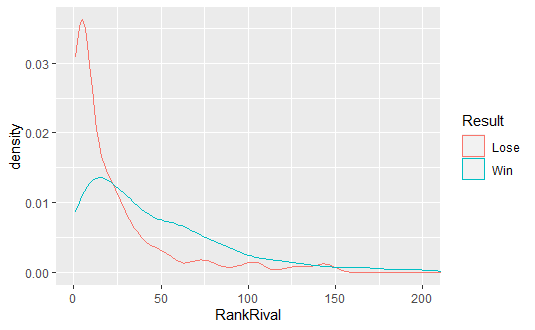

```r
matches_nadal_ok %>% ggplot() +
  geom_density(aes(x = RankRival, color = Result)) +
  coord_cartesian(xlim = c(0, 200))
```

```r
# Partidos ultimos 3 meses

partidos_rival_ult3 <- function(fecha, rival) {

  p <- c()

  for (i in 1:length(fecha)) {

    p <- c(p,
           matches %>%
             filter(Date <= fecha[[i]] &
                      Date > (fecha[[i]]-3*30)) %>%
             filter(Winner == rival[[i]] |
                      Loser == rival[[i]]) %>%
             nrow()
    )

  }

  p

}

matches_nadal_ok$PartidosRivalUlt3Meses <-
  partidos_rival_ult3(matches_nadal_ok$Date,
                      matches_nadal_ok$RivalName)

tail(matches_nadal_ok[,c("Date", "Result",
                         "RivalName", "PartidosRivalUlt3Meses")],
     n = 20)
```

| Date | Result | RivalName | PartidosRivalUlt3Meses |
| --- | --- | --- | --- |
| 2021-04-16 | Lose | Rublev A. | 25 |
| 2021-04-21 | Win | Ivashka I. | 8 |
| 2021-04-22 | Win | Nishikori K. | 14 |
| 2021-04-23 | Win | Norrie C. | 18 |
| 2021-04-24 | Win | Carreno Busta P. | 15 |
| 2021-04-25 | Win | Tsitsipas S. | 31 |
| 2021-05-05 | Win | Alcaraz C. | 12 |
| 2021-05-06 | Win | Popyrin A. | 20 |
| 2021-05-07 | Lose | Zverev A. | 19 |
| 2021-05-12 | Win | Sinner J. | 23 |

[output cut: 10 more lines]

```r
# Partidos rivel ultimo mes

partidos_rival_ultmes <- function(fecha, rival) {

  p <- c()

  for (i in 1:length(fecha)) {

    p <- c(p,
           matches %>%
             filter(Date <= fecha[[i]] &
                      Date > (fecha[[i]]-1*30)) %>%
             filter(Winner == rival[[i]] |
                      Loser == rival[[i]]) %>%
             nrow()
    )

  }

  p

}

matches_nadal_ok$PartidosRivalUltMes <-
  partidos_rival_ultmes(matches_nadal_ok$Date,
                      matches_nadal_ok$RivalName)

tail(matches_nadal_ok[,c("Date", "Result",
                         "RivalName", "PartidosRivalUltMes")],
     n = 20)
```

| Date | Result | RivalName | PartidosRivalUltMes |
| --- | --- | --- | --- |
| 2021-04-16 | Lose | Rublev A. | 10 |
| 2021-04-21 | Win | Ivashka I. | 7 |
| 2021-04-22 | Win | Nishikori K. | 5 |
| 2021-04-23 | Win | Norrie C. | 6 |
| 2021-04-24 | Win | Carreno Busta P. | 11 |
| 2021-04-25 | Win | Tsitsipas S. | 14 |
| 2021-05-05 | Win | Alcaraz C. | 8 |
| 2021-05-06 | Win | Popyrin A. | 8 |
| 2021-05-07 | Lose | Zverev A. | 7 |
| 2021-05-12 | Win | Sinner J. | 10 |

[output cut: 10 more lines]

```r
NA
```

Así como hicimos con Nadal, para el rival calculamos los partidos ganados.

```r
partidos_ganadosrival_ult6 <- function(fecha, rival) {

  p <- c()

  for (i in 1:length(fecha)) {

    p <- c(p,
           matches %>%
             filter(Date <= fecha[[i]] &
                      Date > (fecha[[i]]-6*30)) %>%
             filter(Winner == rival[[i]]) %>%
             nrow()
    )

  }

  p

}

matches_nadal_ok$PartidosGanadosRivalUlt6 <-
  partidos_ganadosrival_ult6(matches_nadal_ok$Date,
                        matches_nadal_ok$RivalName)


tail(matches_nadal_ok[,c("Date", "Result",
                         "RivalName", "PartidosRivalUlt6Meses",
                         "PartidosGanadosRivalUlt6")],
     n = 20)
```

| Date | Result | RivalName | PartidosRivalUlt6Meses | PartidosGanadosRivalUlt6 |
| --- | --- | --- | --- | --- |
| 2021-04-16 | Lose | Rublev A. | 35 | 28 |
| 2021-04-21 | Win | Ivashka I. | 8 | 4 |
| 2021-04-22 | Win | Nishikori K. | 14 | 8 |
| 2021-04-23 | Win | Norrie C. | 23 | 14 |
| 2021-04-24 | Win | Carreno Busta P. | 20 | 14 |
| 2021-04-25 | Win | Tsitsipas S. | 37 | 27 |
| 2021-05-05 | Win | Alcaraz C. | 15 | 7 |
| 2021-05-06 | Win | Popyrin A. | 23 | 15 |
| 2021-05-07 | Lose | Zverev A. | 22 | 15 |
| 2021-05-12 | Win | Sinner J. | 30 | 21 |

[output cut: 10 more lines]

```r
# Partidos ganados rival ultimos 3 meses

partidos_ganadosrival_ult3 <- function(fecha, rival) {

  p <- c()

  for (i in 1:length(fecha)) {

    p <- c(p,
           matches %>%
             filter(Date <= fecha[[i]] &
                      Date > (fecha[[i]]-3*30)) %>%
             filter(Winner == rival[[i]]) %>%
             nrow()
    )

  }

  p

}

matches_nadal_ok$PartidosGanadosRivalUlt3 <-
  partidos_ganadosrival_ult3(matches_nadal_ok$Date,
                             matches_nadal_ok$RivalName)


tail(matches_nadal_ok[,c("Date", "Result",
                         "RivalName", "PartidosRivalUlt3Meses",
                         "PartidosGanadosRivalUlt3")],
     n = 20)
```

| Date | Result | RivalName | PartidosRivalUlt3Meses | PartidosGanadosRivalUlt3 |
| --- | --- | --- | --- | --- |
| 2021-04-16 | Lose | Rublev A. | 25 | 21 |
| 2021-04-21 | Win | Ivashka I. | 8 | 4 |
| 2021-04-22 | Win | Nishikori K. | 14 | 8 |
| 2021-04-23 | Win | Norrie C. | 18 | 11 |
| 2021-04-24 | Win | Carreno Busta P. | 15 | 11 |
| 2021-04-25 | Win | Tsitsipas S. | 31 | 25 |
| 2021-05-05 | Win | Alcaraz C. | 12 | 5 |
| 2021-05-06 | Win | Popyrin A. | 20 | 13 |
| 2021-05-07 | Lose | Zverev A. | 19 | 14 |
| 2021-05-12 | Win | Sinner J. | 23 | 15 |

[output cut: 10 more lines]

```r
# Partidos ganados rival ultimo mes

partidos_ganadosrival_ultmes <- function(fecha, rival) {

  p <- c()

  for (i in 1:length(fecha)) {

    p <- c(p,
           matches %>%
             filter(Date <= fecha[[i]] &
                      Date > (fecha[[i]]-1*30)) %>%
             filter(Winner == rival[[i]]) %>%
             nrow()
    )

  }

  p

}

matches_nadal_ok$PartidosGanadosRivalUltmes <-
  partidos_ganadosrival_ultmes(matches_nadal_ok$Date,
                             matches_nadal_ok$RivalName)


tail(matches_nadal_ok[,c("Date", "Result",
                         "RivalName", "PartidosRivalUltMes",
                         "PartidosGanadosRivalUltmes")],
     n = 20)
```

| Date | Result | RivalName | PartidosRivalUltMes | PartidosGanadosRivalUltmes |
| --- | --- | --- | --- | --- |
| 2021-04-16 | Lose | Rublev A. | 10 | 8 |
| 2021-04-21 | Win | Ivashka I. | 7 | 4 |
| 2021-04-22 | Win | Nishikori K. | 5 | 3 |
| 2021-04-23 | Win | Norrie C. | 6 | 4 |
| 2021-04-24 | Win | Carreno Busta P. | 11 | 9 |
| 2021-04-25 | Win | Tsitsipas S. | 14 | 12 |
| 2021-05-05 | Win | Alcaraz C. | 8 | 4 |
| 2021-05-06 | Win | Popyrin A. | 8 | 4 |
| 2021-05-07 | Lose | Zverev A. | 7 | 5 |
| 2021-05-12 | Win | Sinner J. | 10 | 6 |

[output cut: 10 more lines]

```r
NA
NA
```

Por último, calculo los win rates del rival.

```r
matches_nadal_ok$WRRivalUlt6Meses <-
  matches_nadal_ok$PartidosGanadosRivalUlt6/matches_nadal_ok$PartidosRivalUlt6Meses

matches_nadal_ok$WRRivalUlt3Meses <-
  matches_nadal_ok$PartidosGanadosRivalUlt3/matches_nadal_ok$PartidosRivalUlt3Meses

matches_nadal_ok$WRRivalUltMes <-
  matches_nadal_ok$PartidosGanadosRivalUltmes/matches_nadal_ok$PartidosRivalUltMes

# Achico dataset

glimpse(matches_nadal_ok)
```

```
Rows: 1,129
Columns: 40
$ Location                   <fct> Doha, Doha, Doha, Auckland, Melbourne, Melb~
$ Tournament                 <chr> "Qatar Exxon Mobil Open", "Qatar Exxon Mobi~
$ Date                       <date> 2005-01-04, 2005-01-05, 2005-01-06, 2005-0~
$ Series                     <fct> International, International, International~
$ Court                      <fct> Outdoor, Outdoor, Outdoor, Outdoor, Outdoor~
$ Surface                    <fct> Hard, Hard, Hard, Hard, Hard, Hard, Hard, H~
$ Round                      <fct> 1st Round, 2nd Round, Quarterfinals, 1st Ro~
$ BestOf                     <fct> 3, 3, 3, 3, 5, 5, 5, 5, 3, 3, 3, 3, 3, 3, 3~
$ W1                         <dbl> 6, 6, 6, 6, 6, 6, 6, 7, 7, 6, 0, 7, 6, 6, 2~
$ L1                         <dbl> 3, 2, 2, 3, 0, 1, 1, 5, 6, 1, 6, 6, 3, 2, 6~
$ W2                         <dbl> 7, 6, 6, NA, 6, 4, 6, 3, 6, 6, 6, 6, 6, 6, ~
$ L2                         <dbl> 6, 4, 7, NA, 4, 6, 1, 6, 3, 3, 0, 3, 3, 7, ~
$ W3                         <dbl> NA, NA, 6, NA, 6, 4, 6, 1, NA, NA, 6, NA, N~
```

[output cut: 27 more lines]

```r
matches_nadal_ok <- matches_nadal_ok[,-c(37, 36, 35)]

summary(matches_nadal_ok)
```

```
        Location    Tournament             Date                      Series
 Paris      :139   Length:1129        Min.   :2005-01-04   Masters 1000 :340
 London     : 90   Class :character   1st Qu.:2008-05-15   Grand Slam   :324
 Melbourne  : 81   Mode  :character   Median :2011-11-24   Masters      :134
 Monte Carlo: 76                      Mean   :2012-05-12   ATP500       :133
 Rome       : 75                      3rd Qu.:2016-02-18   ATP250       : 61
 New York   : 72                      Max.   :2021-06-11   International: 58
 (Other)    :596                                           (Other)      : 79
     Court        Surface              Round     BestOf        W1
 Indoor : 109   Carpet:  8   2nd Round    :241   3:796   Min.   :0.000
 Outdoor:1020   Clay  :459   Quarterfinals:207   5:333   1st Qu.:6.000
                Grass : 88   3rd Round    :181           Median :6.000
                Hard  :574   Semifinals   :166           Mean   :5.875
                             The Final    :122           3rd Qu.:6.000
                             1st Round    :113           Max.   :7.000
                             (Other)      : 99           NA's   :16
       L1              W2             L2              W3              L3
 Min.   :0.000   Min.   :0.00   Min.   :0.000   Min.   :0.000   Min.   :0.000
 1st Qu.:2.000   1st Qu.:6.00   1st Qu.:2.000   1st Qu.:6.000   1st Qu.:2.000
 Median :4.000   Median :6.00   Median :3.000   Median :6.000   Median :3.000
 Mean   :3.588   Mean   :5.89   Mean   :3.423   Mean   :6.029   Mean   :3.315
 3rd Qu.:5.000   3rd Qu.:6.00   3rd Qu.:5.000   3rd Qu.:6.000   3rd Qu.:4.500
 Max.   :7.000   Max.   :7.00   Max.   :7.000   Max.   :7.000   Max.   :7.000
 NA's   :15      NA's   :22     NA's   :22      NA's   :614     NA's   :614
       W4              L4              W5               L5
 Min.   :2.000   Min.   :0.000   Min.   : 2.000   Min.   : 0.000
 1st Qu.:6.000   1st Qu.:2.000   1st Qu.: 6.000   1st Qu.: 2.250
 Median :6.000   Median :4.000   Median : 6.000   Median : 4.000
 Mean   :5.837   Mean   :3.683   Mean   : 6.706   Mean   : 4.206
 3rd Qu.:6.000   3rd Qu.:5.250   3rd Qu.: 7.000   3rd Qu.: 5.750
 Max.   :7.000   Max.   :7.000   Max.   :15.000   Max.   :13.000
 NA's   :1025    NA's   :1025    NA's   :1095     NA's   :1095
     Wsets           Lsets                Comment      Result
 Min.   :0.000   Min.   :0.0000   Awarded     :   0   Lose:179
 1st Qu.:2.000   1st Qu.:0.0000   Completed   :1087   Win :950
 Median :2.000   Median :0.0000   Disqualified:   0
 Mean   :2.263   Mean   :0.2971   Retired     :  26
 3rd Qu.:3.000   3rd Qu.:1.0000   Sched       :   1
 Max.   :3.000   Max.   :2.0000   Walkover    :  15
 NA's   :14      NA's   :15
```

[output cut: 16 more lines]

```
    WRUltMes      PartidosRivalUlt6Meses PartidosRivalUlt3Meses
 Min.   :0.0000   Min.   : 1.00          Min.   : 1.00
 1st Qu.:0.8000   1st Qu.:16.00          1st Qu.:10.00
 Median :0.8889   Median :25.00          Median :15.00
 Mean   :0.8709   Mean   :24.96          Mean   :14.88
 3rd Qu.:1.0000   3rd Qu.:33.00          3rd Qu.:20.00
 Max.   :1.0000   Max.   :57.00          Max.   :37.00

 PartidosRivalUltMes WRRivalUlt6Meses WRRivalUlt3Meses WRRivalUltMes
 Min.   : 1.000      Min.   :0.0000   Min.   :0.0000   Min.   :0.0000
 1st Qu.: 4.000      1st Qu.:0.4783   1st Qu.:0.5000   1st Qu.:0.5000
 Median : 6.000      Median :0.5946   Median :0.6111   Median :0.6364
 Mean   : 6.753      Mean   :0.5813   Mean   :0.5886   Mean   :0.6048
 3rd Qu.: 9.000      3rd Qu.:0.6970   3rd Qu.:0.7273   3rd Qu.:0.7500
 Max.   :17.000      Max.   :1.0000   Max.   :1.0000   Max.   :1.0000
```

Calculo métricas del último partido jugado, dato que puede ser importante.

```r
# Sets ganados por nadal y por el rival

matches_nadal_ok$SetsNadal <- rep(NA, nrow(matches_nadal_ok))
matches_nadal_ok$SetsNadal[ganados] <-
  matches_nadal_ok$Wsets[ganados]
matches_nadal_ok$SetsNadal[perdidos] <-
  matches_nadal_ok$Lsets[perdidos]

matches_nadal_ok$SetsRival <- rep(NA, nrow(matches_nadal_ok))
matches_nadal_ok$SetsRival[ganados] <-
  matches_nadal_ok$Lsets[ganados]
matches_nadal_ok$SetsRival[perdidos] <-
  matches_nadal_ok$Wsets[perdidos]

matches_nadal_ok <- matches_nadal_ok[,-c(19,20)]

glimpse(matches_nadal_ok)
```

```
Rows: 1,129
Columns: 37
$ Location               <fct> Doha, Doha, Doha, Auckland, Melbourne, Melbourn~
$ Tournament             <chr> "Qatar Exxon Mobil Open", "Qatar Exxon Mobil Op~
$ Date                   <date> 2005-01-04, 2005-01-05, 2005-01-06, 2005-01-11~
$ Series                 <fct> International, International, International, In~
$ Court                  <fct> Outdoor, Outdoor, Outdoor, Outdoor, Outdoor, Ou~
$ Surface                <fct> Hard, Hard, Hard, Hard, Hard, Hard, Hard, Hard,~
$ Round                  <fct> 1st Round, 2nd Round, Quarterfinals, 1st Round,~
$ BestOf                 <fct> 3, 3, 3, 3, 5, 5, 5, 5, 3, 3, 3, 3, 3, 3, 3, 3,~
$ W1                     <dbl> 6, 6, 6, 6, 6, 6, 6, 7, 7, 6, 0, 7, 6, 6, 2, 6,~
$ L1                     <dbl> 3, 2, 2, 3, 0, 1, 1, 5, 6, 1, 6, 6, 3, 2, 6, 0,~
$ W2                     <dbl> 7, 6, 6, NA, 6, 4, 6, 3, 6, 6, 6, 6, 6, 6, 6, 6~
$ L2                     <dbl> 6, 4, 7, NA, 4, 6, 1, 6, 3, 3, 0, 3, 3, 7, 2, 7~
$ W3                     <dbl> NA, NA, 6, NA, 6, 4, 6, 1, NA, NA, 6, NA, NA, 6~
```

[output cut: 24 more lines]

```r
matches_nadal_ok2 <- as.data.frame(matches_nadal_ok)
matches_nadal_ok <- as_tibble(matches_nadal_ok2)
rm(matches_nadal_ok2)

# Sets ganados y perdidos nadal ultimo partido

sets_ganadosnadal_ult <- function() {

  p <- 0

  for (i in (1:(nrow(matches_nadal_ok))-1)) {

    p <- c(p,
           matches_nadal_ok$SetsNadal[i])

  }

  p

}

matches_nadal_ok$SetsGanadosUltPartido <-
  sets_ganadosnadal_ult()


sets_perdidosnadal_ult <- function() {

  p <- 0

  for (i in (1:(nrow(matches_nadal_ok))-1)) {

    p <- c(p,
           matches_nadal_ok$SetsRival[i])

  }

  p

}

matches_nadal_ok$SetsPerdidosUltPartido <-
 sets_perdidosnadal_ult()

# Resultado ult partido y ronda

matches_nadal_ok$ResultUltPartido <-
  c(NA,
    as.character(matches_nadal_ok$Result[1:nrow(matches_nadal_ok)-1]))

matches_nadal_ok$RoundUltPartido <-
  c(NA,
    as.character(matches_nadal_ok$Round[1:nrow(matches_nadal_ok)-1]))
```

Calculo el H2H entre ambos rivales.

```r
H2H_cantidad <- function (date) {

  p <- c()

  for (i in 1:length(date)) {

    p <- c(p,
           matches_nadal_ok %>%
             filter(Date < date[[i]] &
                      RivalName == RivalName[[i]]) %>%
              nrow()
          )
  }

  p

}

matches_nadal_ok$H2HPartidos <-
  H2H_cantidad(matches_nadal_ok$Date)


#H2H ganados

H2H_ganados <- function (date) {

  p <- c()

  for (i in 1:length(date)) {

    p <- c(p,
           matches_nadal_ok %>%
             filter(Date < date[[i]] &
                      RivalName == RivalName[[i]] &
                      Result == "Win") %>%
             nrow()
    )
  }

  p

}

matches_nadal_ok$H2HGanados <-
  H2H_ganados(matches_nadal_ok$Date)

matches_nadal_ok$H2HWR <-
  matches_nadal_ok$H2HGanados / matches_nadal_ok$H2HPartidos
```

Por último, exporto el dataset que luego será input de análisis estadístico.

```r
save(matches_nadal_ok,
     file = "Output/matches_nadal_ok.Rdata")
warnings()

matches_nadal_ok %>%
  write.csv("Output/matches_nadal_ok.csv")
```